# Beta proportion distribution

Jussi Huotari

2020-11-27

Stan has [Beta Proportion Distribution](https://mc-stan.org/docs/2_25/functions-reference/beta-proportion-distribution.html) for modeling a continuous random variable that takes values between (0, 1). The distribution was implemented in [stan-dev/math#914](https://github.com/stan-dev/math/issues/914).

The parameters are mu and kappa, where $\mu \in (0,1)$ and $\kappa > 0$.

$$\begin{aligned}
\mu & = \frac{\alpha}{\alpha+\beta} \\
\kappa & = \alpha+\beta
\end{aligned}$$

For example, if $\alpha = 2$ and $\beta = 8$, then $\mu = 0.2$ and $\kappa = 10$.

Let’s fit a simple linear regression to see how to use the distribution to model data.

```r
library("ggplot2")
library("bayesplot")
library("dplyr")
library("rstan")
```

# 1 Example data

Let’s simulate some [Beta distributed](https://en.wikipedia.org/wiki/Beta_distribution) data.

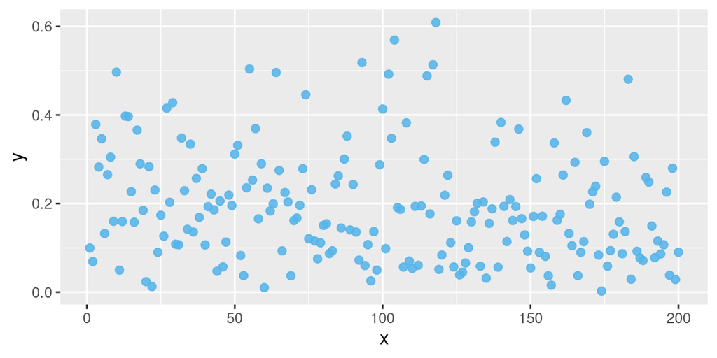

```r
n <- 200
d <- data.frame(y = rbeta(n, 2, 8), x = 1:n)
(ggd <- ggplot(data = d, aes(x=x, y=y)) +
  geom_point(color = "#56B4E9DD", size = 2))
```

# 2 Model: Simple Beta

$$\begin{aligned}
y & \sim BetaProportion(\mu, \kappa) \\
\mu & \sim U(0, 1) \\
\kappa & \sim N(10, 5), >0
\end{aligned}$$

```r
stan_data <- list(N = nrow(d), y = d$y)
fit <- stan("simple_beta_proportion.stan", data = stan_data, refresh = 0,
            iter = 1000, seed = 42)
cat(get_stancode(fit))
```

```
## data {
##   int<lower=0> N;
##   vector[N] y;     // target
## }
##
## parameters {
##   real<lower=0, upper=1> mu;
##   real<lower=0> kappa;
## }
##
## model {
##   mu ~ uniform(0, 1);
##   kappa ~ normal(10, 5);
##   y ~ beta_proportion(mu, kappa);
## }
##
## generated quantities {
##   vector[N] yrep;
##   for (n in 1:N) {
##     yrep[n] = beta_proportion_rng(mu, kappa);
##   }
## }
```

```r
print(fit, pars = c("mu", "kappa"), probs = c(.05, .5, .95))
```

```
## Inference for Stan model: simple_beta_proportion.
## 4 chains, each with iter=1000; warmup=500; thin=1;
## post-warmup draws per chain=500, total post-warmup draws=2000.
##
##       mean se_mean   sd   5%  50%   95% n_eff Rhat
## mu    0.19    0.00 0.01 0.18 0.19  0.21  1185    1
## kappa 8.83    0.02 0.86 7.49 8.80 10.35  1394    1
##
## Samples were drawn using NUTS(diag_e) at Fri Dec  4 11:27:01 2020.
## For each parameter, n_eff is a crude measure of effective sample size,
## and Rhat is the potential scale reduction factor on split chains (at
## convergence, Rhat=1).
```

The model fits properly, with good Rhat and n_eff values. The plots show that posterior parameter values are close to the values used to create the simulated data set, i.e. $\mu = 0.2$ and $\kappa = 10$.

## 2.1 Plot parameter estimates

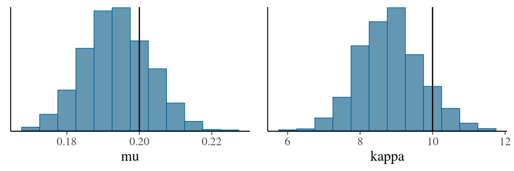

```r
bayesplot_grid( grid_args = list(ncol=2),
  mcmc_hist(fit, pars = "mu", binwidth = .005) + vline_at(.2),
  mcmc_hist(fit, pars = "kappa", binwidth = .5) + vline_at(10)
)
```

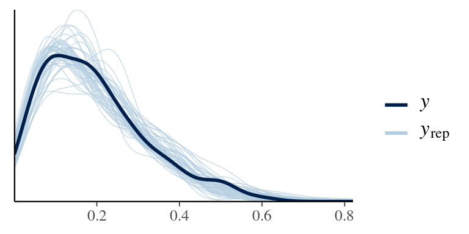

```r
yrep <- extract(fit, pars = 'yrep')$yrep
ppc_dens_overlay(d$y, yrep[1:50, ])
```

# 3 Model with predictor

Using x as a predictor, the model is

$$\begin{aligned}
y_{i} & \sim BetaProportion(\mu_i, \kappa) \\
logit(\mu_i) & = a + b \times x \\
\kappa & \sim N(10, 5), >0
\end{aligned}$$

Using the same data, *b* should be 0. Because of the [logit](https://en.wikipedia.org/wiki/Logit) link function, *a* should be interpreted with the transformation in mind. Let’s see.

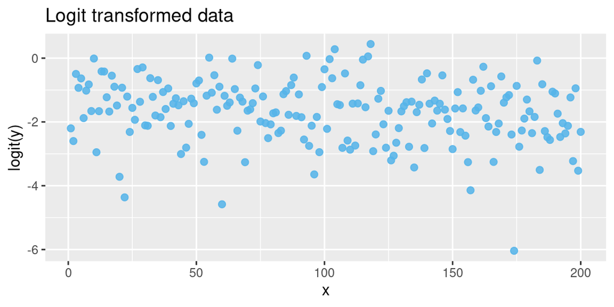

```r
logit <- function(p) log(p/(1-p))
inv_logit <- function(p) 1/(1+exp(-p))
ggplot(data = d, aes(x=x, y=logit(y))) +
  geom_point(color = "#56B4E9DD", size = 2) +
  labs(title = "Logit transformed data")
```

```r
stan_data <- list(N = nrow(d), y = d$y, x = d$x)
fit <- stan("linear_beta_proportion.stan", data = stan_data, refresh = 0,
            iter = 1000, seed = 42)
cat(get_stancode(fit))
```

```
## data {
##   int<lower=0> N;
##   vector[N] y;     // target
##   vector[N] x;     // predictor
## }
##
## parameters {
##   real a;
##   real b;
##   real<lower=0> kappa;
## }
##
## transformed parameters {
##   vector[N] mu = a + b * x;
##   vector[N] theta = inv_logit(mu);
## }
##
## model {
##   a ~ normal(.3, .5);
##   b ~ normal(0, .5);
##   kappa ~ normal(10, 5);
##   y ~ beta_proportion(theta, kappa);
## }
##
## generated quantities {
##   vector[N] yrep;
##   for (n in 1:N) {
##     yrep[n] = beta_proportion_rng(theta[n], kappa);
##   }
## }
```

```r
print(fit, pars = c("a", "b", "kappa"), probs = c(.05, .5, .95))
```

```
## Inference for Stan model: linear_beta_proportion.
## 4 chains, each with iter=1000; warmup=500; thin=1;
## post-warmup draws per chain=500, total post-warmup draws=2000.
##
##        mean se_mean  sd    5%   50%   95% n_eff Rhat
## a     -1.13    0.00 0.1 -1.30 -1.13 -0.97   670    1
## b      0.00    0.00 0.0  0.00  0.00  0.00   943    1
## kappa  9.08    0.03 0.9  7.64  9.04 10.58   694    1
##
## Samples were drawn using NUTS(diag_e) at Fri Dec  4 11:28:11 2020.
## For each parameter, n_eff is a crude measure of effective sample size,
## and Rhat is the potential scale reduction factor on split chains (at
## convergence, Rhat=1).
```

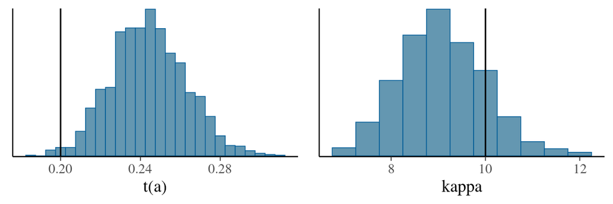

```r
bayesplot_grid( grid_args = list(ncol=2),
  mcmc_hist(fit, pars = "a", transform = inv_logit, binwidth = .005) + vline_at(.2),
  mcmc_hist(fit, pars = "kappa", binwidth = .5) + vline_at(10)
)
```

# 4 Data with slope

In the previous example, the predictor x had no effect. Let’s spice up the data by making it a time series with a slight upward trend.

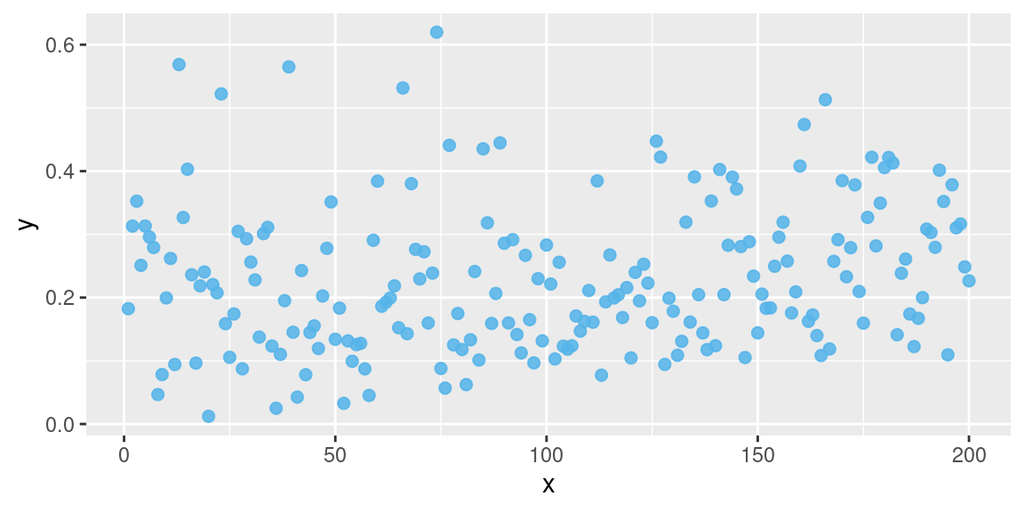

```r
beta_with_slope <- rbeta(n, 2, 8) + seq(from = 0, to = .1, length.out = n)
d <- data.frame(y = beta_with_slope, x = 1:n)
(ggd <- ggplot(data = d, aes(x=x, y=y)) +
  geom_point(color = "#56B4E9DD", size = 2))
```

## 4.1 Fit to new data

```r
stan_data <- list(N = nrow(d), y = d$y, x = d$x)
fit <- stan(fit = fit, data = stan_data, refresh = 0, seed = 42)
print(fit, pars = c("a", "b", "kappa"), probs = c(.05, .5, .95))
```

```
## Inference for Stan model: linear_beta_proportion.
## 4 chains, each with iter=2000; warmup=1000; thin=1;
## post-warmup draws per chain=1000, total post-warmup draws=4000.
##
##        mean se_mean   sd    5%   50%   95% n_eff Rhat
## a     -1.40    0.00 0.09 -1.55 -1.40 -1.25  1542    1
## b      0.00    0.00 0.00  0.00  0.00  0.00  1849    1
## kappa 12.61    0.03 1.24 10.60 12.59 14.71  1283    1
##
## Samples were drawn using NUTS(diag_e) at Fri Dec  4 11:28:46 2020.
## For each parameter, n_eff is a crude measure of effective sample size,
## and Rhat is the potential scale reduction factor on split chains (at
## convergence, Rhat=1).
```

## 4.2 Validate the estimate

I like to refer to [Robust Statistical Workflow with RStan](https://mc-stan.org/users/documentation/case-studies/rstan_workflow.html) to check the reliability of the results. The utilities are implemented conveniently in Rstan [`check_hmc_diagnostics`](https://www.rdocumentation.org/packages/rstan/versions/2.21.2/topics/check_hmc_diagnostics)

```r
check_hmc_diagnostics(fit)
```

```
##
## Divergences:
```

```
## 0 of 4000 iterations ended with a divergence.
```

```
##
## Tree depth:
```

```
## 0 of 4000 iterations saturated the maximum tree depth of 10.
```

```
##
## Energy:
```

```
## E-BFMI indicated no pathological behavior.
```

## 4.3 Plot

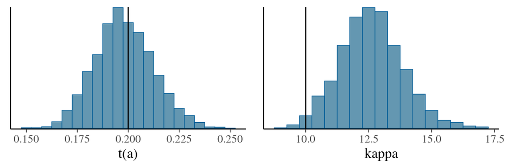

```r
bayesplot_grid( grid_args = list(ncol=2),
  mcmc_hist(fit, pars = "a", transform = inv_logit, binwidth = .005) + vline_at(.2),
  mcmc_hist(fit, pars = "kappa", binwidth = .5) + vline_at(10)
)
```

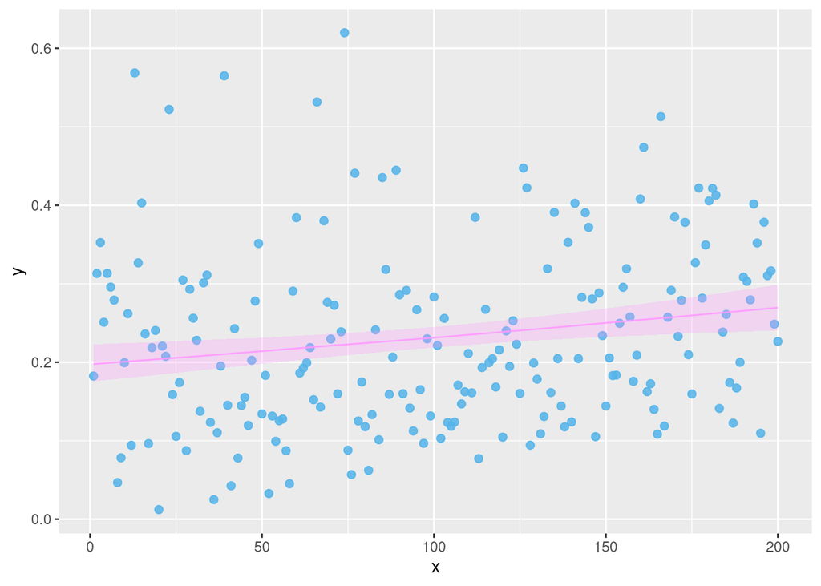

```r
theta <- apply(extract(fit)$theta, 2, quantile, c(0.05, 0.5, 0.95)) %>%
  t() %>% data.frame(., x=d$x)
ggd + geom_line(data = theta, aes(y = X50.), color = "#FF99FFDD") +
  geom_ribbon(data = theta, aes(y = X50., ymin = X5., ymax = X95.), fill = "#FF99FF44")
```

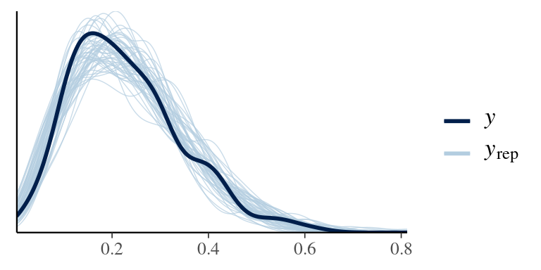

```r
yrep <- extract(fit, pars = 'yrep')$yrep
ppc_dens_overlay(d$y, yrep[1:50, ])
```

# 5 Conclusion

Beta proportion distribution can be used to model a bounded continuous random variable. With a logit link function it’s possible to build a linear model with predictors, and quite convenient to leave data transformation to the Stan code. Though it’s worth considering if it’s linear (enough) after the non-linear data transformation.

A challenge (for me) is the distribution’s parametrization $\mu$ and $\kappa$. How to intuit about $\kappa$? What would be a good weakly informative prior, for example? Branscum, A.J., Johnson, W.O. & Thurmond, M.C. (2007) call $\kappa$ “the parameter related to variance” and suggest using a Gamma prior. In their illustration they use Gamma with mean=1 and variance=1000, which would translate to shape $\alpha$ and rate $\beta$ parameters equal to 0.001, which I would say is a non-informative prior. Laskey (2020) also suggests using Gamma prior. In her case the parameters are shape = 1, rate = 0.05 or mean = 20, variance = 400.

# 6 Dev env

# 7 References

Branscum, A.J., Johnson, W.O. and Thurmond, M.C. (2007), Bayesian Beta Regression: Applications to Household Expenditure Data and Genetic Distance Between Foot‐and‐Mouth Disease Viruses. Australian & New Zealand Journal of Statistics, 49: 287-301. https://doi.org/10.1111/j.1467-842X.2007.00481.x

Laskey, K. (2020), Bayesian Inference and Decision Theory, Unit 7. Lecture slides http://seor.vse.gmu.edu/~klaskey/SYST664/Bayes_Unit7.pdf